# Putting it all together

## Get a feel for the data

Antes de bucear en nuestros datos, debemos comprender antes su estructura básica. Para ello debemos de hacer uso de funciones como **class()**, **dim()** y **names()**.

```r
#Hacemos lectura de los datos
weather <- readRDS("weather.rds")
#Verificamos que tipo es weather
class(weather)
```

```
[1] "data.frame"
```

```r
#Vemos su dimensión
dim(weather)
```

```
[1] 286  35
```

```r
#Comprobamos los nombres de sus columnas
names(weather)
```

```
 [1] "X"       "year"    "month"   "measure" "X1"      "X2"      "X3"      "X4"      "X5"      "X6"      "X7"      "X8"
[13] "X9"      "X10"     "X11"     "X12"     "X13"     "X14"     "X15"     "X16"     "X17"     "X18"     "X19"     "X20"
[25] "X21"     "X22"     "X23"     "X24"     "X25"     "X26"     "X27"     "X28"     "X29"     "X30"     "X31"
```

## Summarize the data

El siguiente paso es ver un resumen de los datos de forma que nos podamos hacer una idea rápida ante que tipos de variables nos estamos enfrentando y ver una descripción estadística básica de cada variable. Para esto podemos hacer uso de **str()** o **glimpse()** y de la función **summary()**

```r
library(dplyr)
#Vemos la estructura de nuestros datos
glimpse(weather)
```

```
Observations: 286
Variables: 35
$ X       <int> 1, 2, 3, 4, 5, 6, 7, 8, 9, 10, 11, 12, 13, 14, 15, 16, 17, 18, 19, 20, 21, 22, 23, 24, 25, 26, 27, 28, 29, ...
$ year    <int> 2014, 2014, 2014, 2014, 2014, 2014, 2014, 2014, 2014, 2014, 2014, 2014, 2014, 2014, 2014, 2014, 2014, 2014,...
$ month   <int> 12, 12, 12, 12, 12, 12, 12, 12, 12, 12, 12, 12, 12, 12, 12, 12, 12, 12, 12, 12, 12, 12, 1, 1, 1, 1, 1, 1, 1...
$ measure <chr> "Max.TemperatureF", "Mean.TemperatureF", "Min.TemperatureF", "Max.Dew.PointF", "MeanDew.PointF", "Min.Dewpo...
$ X1      <chr> "64", "52", "39", "46", "40", "26", "74", "63", "52", "30.45", "30.13", "30.01", "10", "10", "10", "22", "1...
$ X2      <chr> "42", "38", "33", "40", "27", "17", "92", "72", "51", "30.71", "30.59", "30.4", "10", "8", "2", "24", "15",...
$ X3      <chr> "51", "44", "37", "49", "42", "24", "100", "79", "57", "30.4", "30.07", "29.87", "10", "5", "1", "29", "12"...
$ X4      <chr> "43", "37", "30", "24", "21", "13", "69", "54", "39", "30.56", "30.33", "30.09", "10", "10", "10", "25", "1...
$ X5      <chr> "42", "34", "26", "37", "25", "12", "85", "66", "47", "30.68", "30.59", "30.45", "10", "10", "5", "22", "10...
$ X6      <chr> "45", "42", "38", "45", "40", "36", "100", "93", "85", "30.42", "30.24", "30.16", "10", "4", "0", "22", "8"...
$ X7      <chr> "38", "30", "21", "36", "20", "-3", "92", "61", "29", "30.69", "30.46", "30.24", "10", "10", "5", "25", "15...
$ X8      <chr> "29", "24", "18", "28", "16", "3", "92", "70", "47", "30.77", "30.67", "30.51", "10", "8", "2", "21", "13",...
$ X9      <chr> "49", "39", "29", "49", "41", "28", "100", "93", "86", "30.51", "30.04", "29.49", "10", "2", "1", "38", "20...
```

[output cut: 22 more lines]

```r
#Hacemos un resumen estadístico básico
summary(weather)
```

```
       X               year          month          measure               X1                 X2                 X3
 Min.   :  1.00   Min.   :2014   Min.   : 1.000   Length:286         Length:286         Length:286         Length:286
 1st Qu.: 72.25   1st Qu.:2015   1st Qu.: 4.000   Class :character   Class :character   Class :character   Class :character
 Median :143.50   Median :2015   Median : 7.000   Mode  :character   Mode  :character   Mode  :character   Mode  :character
 Mean   :143.50   Mean   :2015   Mean   : 6.923
 3rd Qu.:214.75   3rd Qu.:2015   3rd Qu.:10.000
 Max.   :286.00   Max.   :2015   Max.   :12.000
      X4                 X5                 X6                 X7                 X8                 X9
 Length:286         Length:286         Length:286         Length:286         Length:286         Length:286
 Class :character   Class :character   Class :character   Class :character   Class :character   Class :character
 Mode  :character   Mode  :character   Mode  :character   Mode  :character   Mode  :character   Mode  :character



     X10                X11                X12                X13                X14                X15
 Length:286         Length:286         Length:286         Length:286         Length:286         Length:286
 Class :character   Class :character   Class :character   Class :character   Class :character   Class :character
 Mode  :character   Mode  :character   Mode  :character   Mode  :character   Mode  :character   Mode  :character



     X16                X17                X18                X19                X20                X21
 Length:286         Length:286         Length:286         Length:286         Length:286         Length:286
 Class :character   Class :character   Class :character   Class :character   Class :character   Class :character
 Mode  :character   Mode  :character   Mode  :character   Mode  :character   Mode  :character   Mode  :character



     X22                X23                X24                X25                X26                X27
 Length:286         Length:286         Length:286         Length:286         Length:286         Length:286
 Class :character   Class :character   Class :character   Class :character   Class :character   Class :character
 Mode  :character   Mode  :character   Mode  :character   Mode  :character   Mode  :character   Mode  :character



     X28                X29                X30                X31
 Length:286         Length:286         Length:286         Length:286
 Class :character   Class :character   Class :character   Class :character
 Mode  :character   Mode  :character   Mode  :character   Mode  :character
```

## Take a closer look

Una vez hemos analizado la estructura de nuestros datos, una buena idea es la de visualizar estos, puesto que no es buena idea visualizar el dataset completo, podemos hacer uso de las funciones **head()** y **tail()**, para ver una muestra de nuestro dataset.

```r
#Vemos las 7 primeras observaciones de nuestro dataset
head(weather, n = 7)
```

|  | X | year | month | measure | X1 | X2 | X3 | X4 | X5 | X6 | X7 | X8 | X9 | X10 | X11 | X12 | X13 | X14 | X15 | X16 | X17 | X18 | X19 | X20 | X21 | X22 | X23 | X24 | X25 | … |
| --- | --- | --- | --- | --- | --- | --- | --- | --- | --- | --- | --- | --- | --- | --- | --- | --- | --- | --- | --- | --- | --- | --- | --- | --- | --- | --- | --- | --- | --- | --- |
| 1 | 1 | 2014 | 12 | Max.TemperatureF | 64 | 42 | 51 | 43 | 42 | 45 | 38 | 29 | 49 | 48 | 39 | 39 | 42 | 45 | 42 | 44 | 49 | 44 | 37 | 36 | 36 | 44 | 47 | 46 | 59 | … |
| 2 | 2 | 2014 | 12 | Mean.TemperatureF | 52 | 38 | 44 | 37 | 34 | 42 | 30 | 24 | 39 | 43 | 36 | 35 | 37 | 39 | 37 | 40 | 45 | 40 | 33 | 32 | 33 | 39 | 45 | 44 | 52 | … |
| 3 | 3 | 2014 | 12 | Min.TemperatureF | 39 | 33 | 37 | 30 | 26 | 38 | 21 | 18 | 29 | 38 | 32 | 31 | 32 | 33 | 32 | 35 | 41 | 36 | 29 | 27 | 30 | 33 | 42 | 41 | 44 | … |
| 4 | 4 | 2014 | 12 | Max.Dew.PointF | 46 | 40 | 49 | 24 | 37 | 45 | 36 | 28 | 49 | 45 | 37 | 28 | 28 | 29 | 33 | 42 | 46 | 34 | 25 | 30 | 30 | 39 | 45 | 46 | 58 | … |
| 5 | 5 | 2014 | 12 | MeanDew.PointF | 40 | 27 | 42 | 21 | 25 | 40 | 20 | 16 | 41 | 39 | 31 | 27 | 26 | 27 | 29 | 36 | 41 | 30 | 22 | 24 | 27 | 34 | 42 | 44 | 43 | … |
| 6 | 6 | 2014 | 12 | Min.DewpointF | 26 | 17 | 24 | 13 | 12 | 36 | -3 | 3 | 28 | 37 | 27 | 25 | 24 | 25 | 27 | 30 | 32 | 26 | 20 | 20 | 25 | 25 | 37 | 41 | 29 | … |
| 7 | 7 | 2014 | 12 | Max.Humidity | 74 | 92 | 100 | 69 | 85 | 100 | 92 | 92 | 100 | 100 | 92 | 85 | 75 | 82 | 89 | 96 | 100 | 89 | 69 | 89 | 85 | 89 | 100 | 100 | 100 | … |

```r
#Vemos las últimas 5 observaciones de nuestro dataset
tail(weather, n = 5)
```

|  | X | year | month | measure | X1 | X2 | X3 | X4 | X5 | X6 | X7 | X8 | X9 | X10 | X11 | X12 | X13 | X14 | X15 | X16 | X17 | X18 | X19 | X20 | X21 | X22 | X23 | X24 | X25 | … |
| --- | --- | --- | --- | --- | --- | --- | --- | --- | --- | --- | --- | --- | --- | --- | --- | --- | --- | --- | --- | --- | --- | --- | --- | --- | --- | --- | --- | --- | --- | --- |
| 282 | 282 | 2015 | 12 | Max.Gust.SpeedMPH | 17 | NA | NA | NA | NA | NA | NA | NA | NA | NA | NA | NA | NA | NA | NA | NA | NA | NA | NA | NA | NA | NA | NA | NA | NA | … |
| 283 | 283 | 2015 | 12 | PrecipitationIn | 0.14 | NA | NA | NA | NA | NA | NA | NA | NA | NA | NA | NA | NA | NA | NA | NA | NA | NA | NA | NA | NA | NA | NA | NA | NA | … |
| 284 | 284 | 2015 | 12 | CloudCover | 7 | NA | NA | NA | NA | NA | NA | NA | NA | NA | NA | NA | NA | NA | NA | NA | NA | NA | NA | NA | NA | NA | NA | NA | NA | … |
| 285 | 285 | 2015 | 12 | Events | Rain | NA | NA | NA | NA | NA | NA | NA | NA | NA | NA | NA | NA | NA | NA | NA | NA | NA | NA | NA | NA | NA | NA | NA | NA | … |
| 286 | 286 | 2015 | 12 | WindDirDegrees | 109 | NA | NA | NA | NA | NA | NA | NA | NA | NA | NA | NA | NA | NA | NA | NA | NA | NA | NA | NA | NA | NA | NA | NA | NA | … |

## Column names are values

En nuestro conjunto de datos weather las variables x1-x31 representan días del mes, esto sugiere que podríamos crearnos una columna que fuese day y le asignase su correspondiente temperatura. Para ello podemos hacer uso de la función **gather()**, de la librería **tidyr**.

```r
library(tidyr)
#Hacemos uso de gather
weather2 <- gather(weather, day, value, X1:X31, na.rm = TRUE)
#Vemos las 5 primeras observaciones
head(weather2, n = 5)
```

|  | X | year | month | measure | day | value |
| --- | --- | --- | --- | --- | --- | --- |
| 1 | 1 | 2014 | 12 | Max.TemperatureF | X1 | 64 |
| 2 | 2 | 2014 | 12 | Mean.TemperatureF | X1 | 52 |
| 3 | 3 | 2014 | 12 | Min.TemperatureF | X1 | 39 |
| 4 | 4 | 2014 | 12 | Max.Dew.PointF | X1 | 46 |
| 5 | 5 | 2014 | 12 | MeanDew.PointF | X1 | 40 |

## Values are variable names

Podemos ver como los valores de la variable measure debería de tratarse de nombres de variables. Para esto podemos hacer uso de la función **spread()**.

```r
#En primer lugar eliminamos la columna de indexación
weather2 <- weather2[,-1]
#Hacemos uso de la función spread
weather3 <- spread(weather2, measure, value)
#Vemos las 5 primeras observaciones
head(weather3)
```

|  | year | month | day | CloudCover | Events | Max.Dew.PointF | Max.Gust.SpeedMPH | Max.Humidity | Max.Sea.Level.PressureIn | Max.TemperatureF | Max.VisibilityMiles | Max.Wind.SpeedMPH | MeanDew.PointF | Mean.Humidity | Mean.Sea.Level.PressureIn | Mean.TemperatureF | Mean.VisibilityMiles | Mean.Wind.SpeedMPH | Min.DewpointF | Min.Humidity | Min.Sea.Level.PressureIn | Min.TemperatureF | Min.VisibilityMiles | PrecipitationIn | WindDirDegrees |
| --- | --- | --- | --- | --- | --- | --- | --- | --- | --- | --- | --- | --- | --- | --- | --- | --- | --- | --- | --- | --- | --- | --- | --- | --- | --- |
| 1 | 2014 | 12 | X1 | 6 | Rain | 46 | 29 | 74 | 30.45 | 64 | 10 | 22 | 40 | 63 | 30.13 | 52 | 10 | 13 | 26 | 52 | 30.01 | 39 | 10 | 0.01 | 268 |
| 2 | 2014 | 12 | X10 | 8 | Rain | 45 | 29 | 100 | 29.58 | 48 | 10 | 23 | 39 | 95 | 29.5 | 43 | 3 | 13 | 37 | 89 | 29.43 | 38 | 1 | 0.28 | 357 |
| 3 | 2014 | 12 | X11 | 8 | Rain-Snow | 37 | 28 | 92 | 29.81 | 39 | 10 | 21 | 31 | 87 | 29.61 | 36 | 7 | 13 | 27 | 82 | 29.44 | 32 | 1 | 0.02 | 230 |
| 4 | 2014 | 12 | X12 | 7 | Snow | 28 | 21 | 85 | 29.88 | 39 | 10 | 16 | 27 | 75 | 29.85 | 35 | 10 | 11 | 25 | 64 | 29.81 | 31 | 7 | T | 286 |
| 5 | 2014 | 12 | X13 | 5 |  | 28 | 23 | 75 | 29.86 | 42 | 10 | 17 | 26 | 65 | 29.82 | 37 | 10 | 12 | 24 | 55 | 29.78 | 32 | 10 | T | 298 |
| 6 | 2014 | 12 | X14 | 4 |  | 29 | 20 | 82 | 29.91 | 45 | 10 | 15 | 27 | 68 | 29.83 | 39 | 10 | 10 | 25 | 53 | 29.78 | 33 | 10 | 0.00 | 306 |

## Clean up dates

```r
library(stringr)
library(lubridate)
#Limpiamos los días de la semana
weather3$day <- str_replace(weather3$day, "X", "")
#Unimos las columnas day, year y month
weather4 <- unite(weather3, date, year, month, day, sep = "-")
#Pasamos a tipo date
weather4$date <- ymd(weather4$date)
#Hacemos uso de select para reordenar las columnas de una forma más adecuada
weather5 <- select(weather4, date, Events, CloudCover:WindDirDegrees)
#Vemos las 5 primeras observaciones
head(weather5)
```

|  | date | Events | CloudCover | Max.Dew.PointF | Max.Gust.SpeedMPH | Max.Humidity | Max.Sea.Level.PressureIn | Max.TemperatureF | Max.VisibilityMiles | Max.Wind.SpeedMPH | MeanDew.PointF | Mean.Humidity | Mean.Sea.Level.PressureIn | Mean.TemperatureF | Mean.VisibilityMiles | Mean.Wind.SpeedMPH | Min.DewpointF | Min.Humidity | Min.Sea.Level.PressureIn | Min.TemperatureF | Min.VisibilityMiles | PrecipitationIn | WindDirDegrees |
| --- | --- | --- | --- | --- | --- | --- | --- | --- | --- | --- | --- | --- | --- | --- | --- | --- | --- | --- | --- | --- | --- | --- | --- |
| 1 | 2014-12-01 | Rain | 6 | 46 | 29 | 74 | 30.45 | 64 | 10 | 22 | 40 | 63 | 30.13 | 52 | 10 | 13 | 26 | 52 | 30.01 | 39 | 10 | 0.01 | 268 |
| 2 | 2014-12-10 | Rain | 8 | 45 | 29 | 100 | 29.58 | 48 | 10 | 23 | 39 | 95 | 29.5 | 43 | 3 | 13 | 37 | 89 | 29.43 | 38 | 1 | 0.28 | 357 |
| 3 | 2014-12-11 | Rain-Snow | 8 | 37 | 28 | 92 | 29.81 | 39 | 10 | 21 | 31 | 87 | 29.61 | 36 | 7 | 13 | 27 | 82 | 29.44 | 32 | 1 | 0.02 | 230 |
| 4 | 2014-12-12 | Snow | 7 | 28 | 21 | 85 | 29.88 | 39 | 10 | 16 | 27 | 75 | 29.85 | 35 | 10 | 11 | 25 | 64 | 29.81 | 31 | 7 | T | 286 |
| 5 | 2014-12-13 |  | 5 | 28 | 23 | 75 | 29.86 | 42 | 10 | 17 | 26 | 65 | 29.82 | 37 | 10 | 12 | 24 | 55 | 29.78 | 32 | 10 | T | 298 |
| 6 | 2014-12-14 |  | 4 | 29 | 20 | 82 | 29.91 | 45 | 10 | 15 | 27 | 68 | 29.83 | 39 | 10 | 10 | 25 | 53 | 29.78 | 33 | 10 | 0.00 | 306 |

## A closer look at column types

Para poder realizar un buen análisis es muy importante tener las variables bien codificadas, para ello podemos hacer uso de funciones que nos permiten coercionar variables. Debemos tener muy claro que existen determinadas coerciones que no son posibles de realizar. En la variable **PrecipitationIn** se hizo uso de la letra “T” para hacer referencia a una medida tan sumamente pequeña que era complicada de medir con precisión.

```r
#Vemos la estructura de datos de weather5
glimpse(weather5)
```

```
Observations: 366
Variables: 23
$ date                      <date> 2014-12-01, 2014-12-10, 2014-12-11, 2014-12-12, 2014-12-13, 2014-12-14, 2014-12-15, 2...
$ Events                    <chr> "Rain", "Rain", "Rain-Snow", "Snow", "", "", "", "Rain", "Rain", "Rain", "", "Rain-Sno...
$ CloudCover                <chr> "6", "8", "8", "7", "5", "4", "2", "8", "8", "7", "4", "7", "6", "8", "7", "8", "8", "...
$ Max.Dew.PointF            <chr> "46", "45", "37", "28", "28", "29", "33", "42", "46", "34", "25", "40", "30", "30", "3...
$ Max.Gust.SpeedMPH         <chr> "29", "29", "28", "21", "23", "20", "21", "10", "26", "30", "23", "29", "26", "20", "2...
$ Max.Humidity              <chr> "74", "100", "92", "85", "75", "82", "89", "96", "100", "89", "69", "92", "89", "85", ...
$ Max.Sea.Level.PressureIn  <chr> "30.45", "29.58", "29.81", "29.88", "29.86", "29.91", "30.15", "30.17", "29.91", "29.8...
$ Max.TemperatureF          <chr> "64", "48", "39", "39", "42", "45", "42", "44", "49", "44", "37", "42", "36", "36", "4...
$ Max.VisibilityMiles       <chr> "10", "10", "10", "10", "10", "10", "10", "10", "10", "10", "10", "10", "10", "10", "1...
$ Max.Wind.SpeedMPH         <chr> "22", "23", "21", "16", "17", "15", "15", "8", "20", "23", "17", "24", "21", "16", "18...
$ MeanDew.PointF            <chr> "40", "39", "31", "27", "26", "27", "29", "36", "41", "30", "22", "27", "24", "27", "3...
$ Mean.Humidity             <chr> "63", "95", "87", "75", "65", "68", "75", "85", "85", "73", "63", "72", "79", "77", "7...
$ Mean.Sea.Level.PressureIn <chr> "30.13", "29.5", "29.61", "29.85", "29.82", "29.83", "30.05", "30.09", "29.75", "29.78...
$ Mean.TemperatureF         <chr> "52", "43", "36", "35", "37", "39", "37", "40", "45", "40", "33", "38", "32", "33", "3...
$ Mean.VisibilityMiles      <chr> "10", "3", "7", "10", "10", "10", "10", "9", "6", "10", "10", "8", "10", "9", "10", "5...
$ Mean.Wind.SpeedMPH        <chr> "13", "13", "13", "11", "12", "10", "6", "4", "11", "14", "11", "15", "10", "9", "8", ...
$ Min.DewpointF             <chr> "26", "37", "27", "25", "24", "25", "27", "30", "32", "26", "20", "17", "20", "25", "2...
$ Min.Humidity              <chr> "52", "89", "82", "64", "55", "53", "60", "73", "70", "57", "56", "51", "69", "69", "6...
$ Min.Sea.Level.PressureIn  <chr> "30.01", "29.43", "29.44", "29.81", "29.78", "29.78", "29.91", "29.92", "29.69", "29.7...
$ Min.TemperatureF          <chr> "39", "38", "32", "31", "32", "33", "32", "35", "41", "36", "29", "33", "27", "30", "3...
$ Min.VisibilityMiles       <chr> "10", "1", "1", "7", "10", "10", "10", "5", "1", "10", "10", "2", "7", "6", "4", "1", ...
$ PrecipitationIn           <chr> "0.01", "0.28", "0.02", "T", "T", "0.00", "0.00", "T", "0.43", "0.01", "0.00", "0.10",...
$ WindDirDegrees            <chr> "268", "357", "230", "286", "298", "306", "324", "79", "311", "281", "305", "62", "350...
```

```r
#Cambiamos el valor de T por 0 en la variable PrecipitationIn
weather5$PrecipitationIn <- str_replace(weather5$PrecipitationIn, "T", "0")
#Aplicamos la conversión a tipo numeríco a las columnas que corresponden
weather6 <- mutate_each(weather5, funs(as.numeric), CloudCover:WindDirDegrees)
```

```
`mutate_each()` is deprecated.
Use `mutate_all()`, `mutate_at()` or `mutate_if()` instead.
To map `funs` over a selection of variables, use `mutate_at()`
```

```r
#Vemos la estructura de weather6
glimpse(weather6)
```

```
Observations: 366
Variables: 23
$ date                      <date> 2014-12-01, 2014-12-10, 2014-12-11, 2014-12-12, 2014-12-13, 2014-12-14, 2014-12-15, 2...
$ Events                    <chr> "Rain", "Rain", "Rain-Snow", "Snow", "", "", "", "Rain", "Rain", "Rain", "", "Rain-Sno...
$ CloudCover                <dbl> 6, 8, 8, 7, 5, 4, 2, 8, 8, 7, 4, 7, 6, 8, 7, 8, 8, 6, 1, 3, 8, 4, 8, 2, 1, 3, 5, 8, 6,...
$ Max.Dew.PointF            <dbl> 46, 45, 37, 28, 28, 29, 33, 42, 46, 34, 25, 40, 30, 30, 39, 45, 46, 58, 31, 34, 42, 26...
$ Max.Gust.SpeedMPH         <dbl> 29, 29, 28, 21, 23, 20, 21, 10, 26, 30, 23, 29, 26, 20, 22, 25, 15, 40, 25, 21, 31, 22...
$ Max.Humidity              <dbl> 74, 100, 92, 85, 75, 82, 89, 96, 100, 89, 69, 92, 89, 85, 89, 100, 100, 100, 70, 70, 7...
$ Max.Sea.Level.PressureIn  <dbl> 30.45, 29.58, 29.81, 29.88, 29.86, 29.91, 30.15, 30.17, 29.91, 29.87, 30.15, 30.71, 30...
$ Max.TemperatureF          <dbl> 64, 48, 39, 39, 42, 45, 42, 44, 49, 44, 37, 42, 36, 36, 44, 47, 46, 59, 50, 52, 52, 41...
$ Max.VisibilityMiles       <dbl> 10, 10, 10, 10, 10, 10, 10, 10, 10, 10, 10, 10, 10, 10, 10, 10, 2, 10, 10, 10, 10, 10,...
$ Max.Wind.SpeedMPH         <dbl> 22, 23, 21, 16, 17, 15, 15, 8, 20, 23, 17, 24, 21, 16, 18, 20, 13, 28, 18, 17, 22, 15,...
$ MeanDew.PointF            <dbl> 40, 39, 31, 27, 26, 27, 29, 36, 41, 30, 22, 27, 24, 27, 34, 42, 44, 43, 29, 31, 35, 20...
$ Mean.Humidity             <dbl> 63, 95, 87, 75, 65, 68, 75, 85, 85, 73, 63, 72, 79, 77, 79, 91, 98, 75, 60, 60, 65, 51...
$ Mean.Sea.Level.PressureIn <dbl> 30.13, 29.50, 29.61, 29.85, 29.82, 29.83, 30.05, 30.09, 29.75, 29.78, 29.98, 30.59, 30...
$ Mean.TemperatureF         <dbl> 52, 43, 36, 35, 37, 39, 37, 40, 45, 40, 33, 38, 32, 33, 39, 45, 44, 52, 44, 45, 46, 36...
$ Mean.VisibilityMiles      <dbl> 10, 3, 7, 10, 10, 10, 10, 9, 6, 10, 10, 8, 10, 9, 10, 5, 1, 8, 10, 10, 10, 10, 5, 10, ...
$ Mean.Wind.SpeedMPH        <dbl> 13, 13, 13, 11, 12, 10, 6, 4, 11, 14, 11, 15, 10, 9, 8, 13, 6, 14, 11, 9, 14, 9, 12, 1...
$ Min.DewpointF             <dbl> 26, 37, 27, 25, 24, 25, 27, 30, 32, 26, 20, 17, 20, 25, 25, 37, 41, 29, 28, 29, 27, 10...
$ Min.Humidity              <dbl> 52, 89, 82, 64, 55, 53, 60, 73, 70, 57, 56, 51, 69, 69, 69, 82, 96, 49, 49, 50, 53, 37...
$ Min.Sea.Level.PressureIn  <dbl> 30.01, 29.43, 29.44, 29.81, 29.78, 29.78, 29.91, 29.92, 29.69, 29.71, 29.86, 30.40, 30...
$ Min.TemperatureF          <dbl> 39, 38, 32, 31, 32, 33, 32, 35, 41, 36, 29, 33, 27, 30, 33, 42, 41, 44, 37, 38, 40, 30...
$ Min.VisibilityMiles       <dbl> 10, 1, 1, 7, 10, 10, 10, 5, 1, 10, 10, 2, 7, 6, 4, 1, 0, 1, 10, 10, 10, 10, 1, 10, 10,...
$ PrecipitationIn           <dbl> 0.01, 0.28, 0.02, 0.00, 0.00, 0.00, 0.00, 0.00, 0.43, 0.01, 0.00, 0.10, 0.00, 0.00, 0....
$ WindDirDegrees            <dbl> 268, 357, 230, 286, 298, 306, 324, 79, 311, 281, 305, 62, 350, 2, 24, 63, 12, 250, 255...
```

## Find missing values

Antes de decidir eliminar los valores perdidos es muy importante tener claro en que variables aparecen y en que cantidad.

```r
#Vemos el número de valores perdidos que dispone nuestro dataset
sum(is.na(weather6))
```

```
[1] 6
```

```r
#Hacemos uso de la función summary para ver donde están
summary(weather6)
```

```
      date               Events            CloudCover    Max.Dew.PointF  Max.Gust.SpeedMPH  Max.Humidity
 Min.   :2014-12-01   Length:366         Min.   :0.000   Min.   :-6.00   Min.   : 0.00     Min.   :  39.00
 1st Qu.:2015-03-02   Class :character   1st Qu.:3.000   1st Qu.:32.00   1st Qu.:21.00     1st Qu.:  73.25
 Median :2015-06-01   Mode  :character   Median :5.000   Median :47.50   Median :25.50     Median :  86.00
 Mean   :2015-06-01                      Mean   :4.708   Mean   :45.48   Mean   :26.99     Mean   :  85.69
 3rd Qu.:2015-08-31                      3rd Qu.:7.000   3rd Qu.:61.00   3rd Qu.:31.25     3rd Qu.:  93.00
 Max.   :2015-12-01                      Max.   :8.000   Max.   :75.00   Max.   :94.00     Max.   :1000.00
                                                                         NA's   :6
 Max.Sea.Level.PressureIn Max.TemperatureF Max.VisibilityMiles Max.Wind.SpeedMPH MeanDew.PointF   Mean.Humidity
 Min.   :29.58            Min.   :18.00    Min.   : 2.000      Min.   : 8.00     Min.   :-11.00   Min.   :28.00
 1st Qu.:30.00            1st Qu.:42.00    1st Qu.:10.000      1st Qu.:16.00     1st Qu.: 24.00   1st Qu.:56.00
 Median :30.14            Median :60.00    Median :10.000      Median :20.00     Median : 41.00   Median :66.00
 Mean   :30.16            Mean   :58.93    Mean   : 9.907      Mean   :20.62     Mean   : 38.96   Mean   :66.02
 3rd Qu.:30.31            3rd Qu.:76.00    3rd Qu.:10.000      3rd Qu.:24.00     3rd Qu.: 56.00   3rd Qu.:76.75
 Max.   :30.88            Max.   :96.00    Max.   :10.000      Max.   :38.00     Max.   : 71.00   Max.   :98.00

 Mean.Sea.Level.PressureIn Mean.TemperatureF Mean.VisibilityMiles Mean.Wind.SpeedMPH Min.DewpointF     Min.Humidity
 Min.   :29.49             Min.   : 8.00     Min.   :-1.000       Min.   : 4.00      Min.   :-18.00   Min.   :16.00
 1st Qu.:29.87             1st Qu.:36.25     1st Qu.: 8.000       1st Qu.: 8.00      1st Qu.: 16.25   1st Qu.:35.00
 Median :30.03             Median :53.50     Median :10.000       Median :10.00      Median : 35.00   Median :46.00
 Mean   :30.04             Mean   :51.40     Mean   : 8.861       Mean   :10.68      Mean   : 32.25   Mean   :48.31
 3rd Qu.:30.19             3rd Qu.:68.00     3rd Qu.:10.000       3rd Qu.:13.00      3rd Qu.: 51.00   3rd Qu.:60.00
 Max.   :30.77             Max.   :84.00     Max.   :10.000       Max.   :22.00      Max.   : 68.00   Max.   :96.00

 Min.Sea.Level.PressureIn Min.TemperatureF Min.VisibilityMiles PrecipitationIn  WindDirDegrees
 Min.   :29.16            Min.   :-3.00    Min.   : 0.000      Min.   :0.0000   Min.   :  1.0
 1st Qu.:29.76            1st Qu.:30.00    1st Qu.: 2.000      1st Qu.:0.0000   1st Qu.:113.0
 Median :29.94            Median :46.00    Median :10.000      Median :0.0000   Median :222.0
 Mean   :29.93            Mean   :43.33    Mean   : 6.716      Mean   :0.1016   Mean   :200.1
 3rd Qu.:30.09            3rd Qu.:60.00    3rd Qu.:10.000      3rd Qu.:0.0400   3rd Qu.:275.0
 Max.   :30.64            Max.   :74.00    Max.   :10.000      Max.   :2.9000   Max.   :360.0
```

```r
#También podemos ver los índices en los que se encuentran los valores perdidos
ind <- which(is.na(weather6$Max.Gust.SpeedMPH))
#Finalmente podemos extraer dichas observaciones
weather6[ind,]
```

|  | date | Events | CloudCover | Max.Dew.PointF | Max.Gust.SpeedMPH | Max.Humidity | Max.Sea.Level.PressureIn | Max.TemperatureF | Max.VisibilityMiles | Max.Wind.SpeedMPH | MeanDew.PointF | Mean.Humidity | Mean.Sea.Level.PressureIn | Mean.TemperatureF | Mean.VisibilityMiles | Mean.Wind.SpeedMPH | Min.DewpointF | Min.Humidity | Min.Sea.Level.PressureIn | Min.TemperatureF | Min.VisibilityMiles | PrecipitationIn | WindDirDegrees |
| --- | --- | --- | --- | --- | --- | --- | --- | --- | --- | --- | --- | --- | --- | --- | --- | --- | --- | --- | --- | --- | --- | --- | --- |
| 161 | 2015-05-18 | Fog | 6 | 52 | NA | 100 | 30.30 | 58 | 10 | 16 | 48 | 79 | 30.23 | 54 | 8 | 10 | 43 | 57 | 30.12 | 49 | 0 | 0 | 72 |
| 205 | 2015-06-03 |  | 7 | 48 | NA | 93 | 30.31 | 56 | 10 | 14 | 45 | 82 | 30.24 | 52 | 10 | 7 | 43 | 71 | 30.19 | 47 | 10 | 0 | 90 |
| 273 | 2015-08-08 |  | 4 | 61 | NA | 87 | 30.02 | 76 | 10 | 14 | 57 | 68 | 29.99 | 69 | 10 | 6 | 54 | 49 | 29.95 | 61 | 10 | 0 | 45 |
| 275 | 2015-09-01 |  | 1 | 63 | NA | 78 | 30.06 | 79 | 10 | 15 | 62 | 65 | 30.02 | 74 | 10 | 9 | 59 | 52 | 29.96 | 69 | 10 | 0 | 54 |
| 308 | 2015-10-12 |  | 0 | 56 | NA | 89 | 29.86 | 76 | 10 | 15 | 51 | 65 | 29.80 | 64 | 10 | 8 | 48 | 41 | 29.74 | 51 | 10 | 0 | 199 |
| 358 | 2015-11-03 |  | 1 | 44 | NA | 82 | 30.25 | 73 | 10 | 16 | 42 | 57 | 30.13 | 60 | 10 | 8 | 40 | 31 | 30.06 | 47 | 10 | 0 | 281 |

## An obvious error

Además de conocer los valores perdidos podemos estar interesados en conocer los valores extremos de nuestros datos. Para ello podemos hacer uso de la función **summary()**, si miramos la variable **Max.Humidity** toma como valor máximo 1000, este valor esta realmente desviado de la media. Esto tras consultar con un experto nos dice que fue un errror y realmente ese valor es 100.

```r
#Encontramos el índice
ind <- which(weather6$Max.Humidity == 1000)
#Reemplazamos
weather6$Max.Humidity[ind] <- 100
```

## Another obvious error

Otro error es que podemos ver como la variable **Mean.VisibilityMiles** toma como valor mínimo -1, este valor debería ser realmente 10.

```r
#Encontramos el índice del error
ind <- which(weather6$Mean.VisibilityMiles == -1)

#Reemplazamos
weather6$Mean.VisibilityMiles[ind] <- 10
```

## Check other extreme values

Los histogramas son una buena idea a la hora de encontrar valores extremos

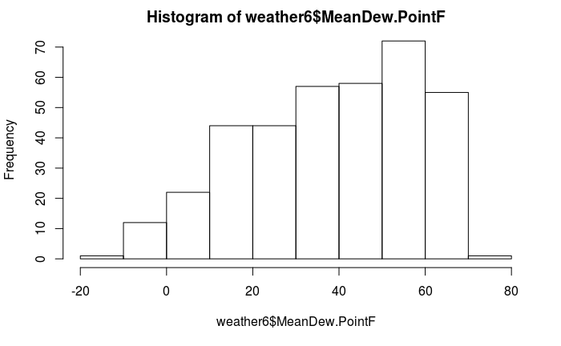

```r
hist(weather6$MeanDew.PointF)
```

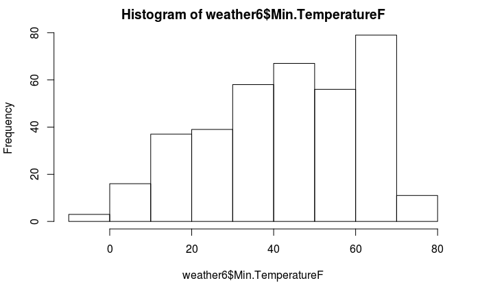

```r
hist(weather6$Min.TemperatureF)
```

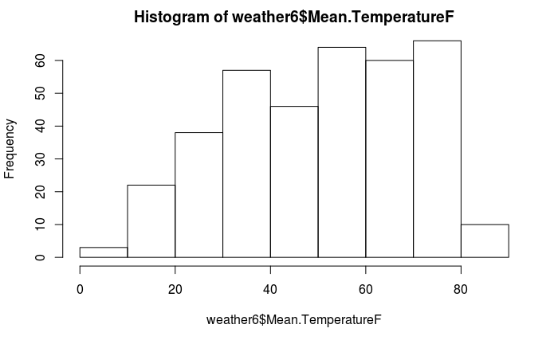

```r
hist(weather6$Mean.TemperatureF)
```